# scRNA-seq learning: R / Seurat

10x Genomics PBMC3k: a cell-called count matrix from one healthy donor.

## Observed results

| metric | value |
| --- | --- |
| implementation | R / Seurat |
| input_cells | 2700 |
| retained_cells | 2542 |
| retained_genes | 13522 |
| clusters | 9 |
| predicted_doublets_before_final_qc | 96 |
| final_counts_total_umi | 5867141 |
| doublet_detection | TRUE |

All displayed results were generated by the R workflow. Candidate labels require manual marker review.

## Quality control by capture

| sample_id | input_cells | kept_cells | predicted_doublets |
| --- | --- | --- | --- |
| pbmc3k | 2700 | 2542 | 96 |

The cell audit records every input cell and every removal reason. scDblFinder operates per physical capture after a minimum-gene screen; final QC follows doublet calling.

## Figures and annotation evidence

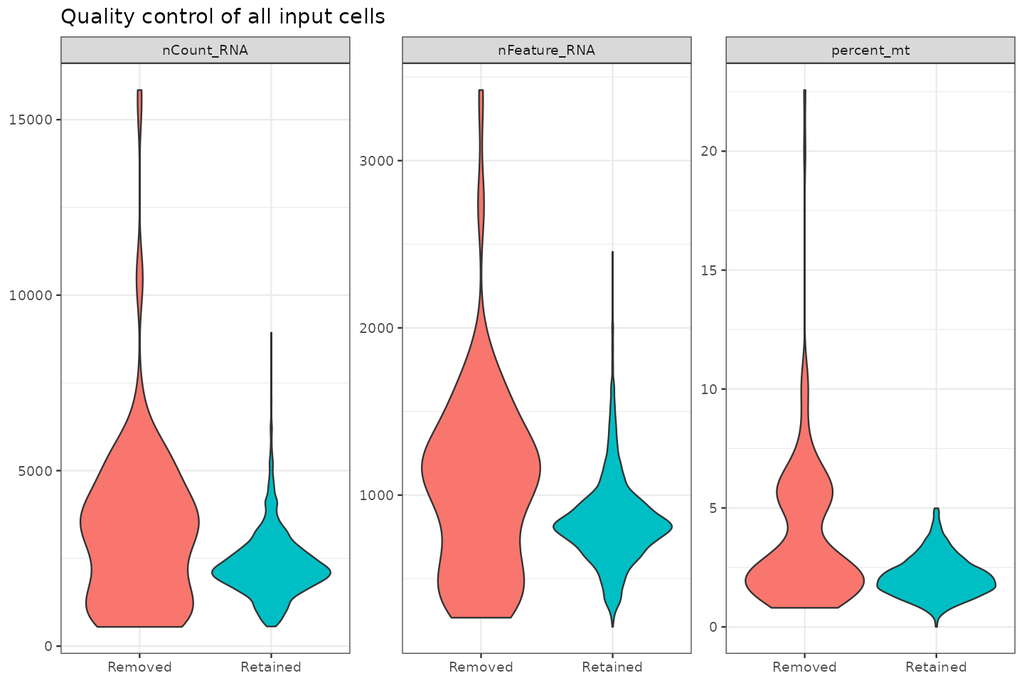

qc.png

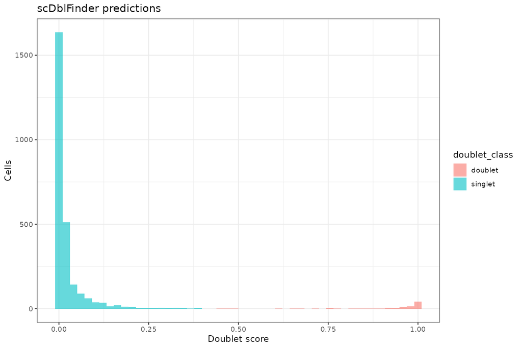

doublets.png

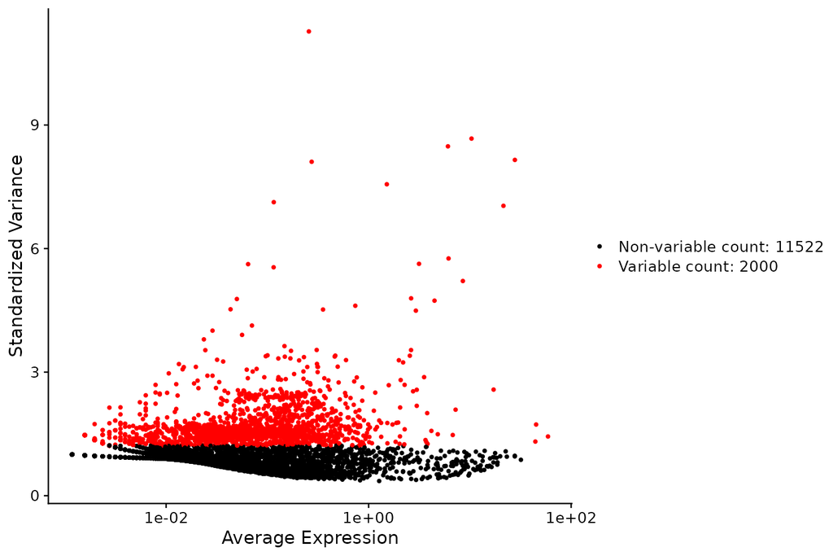

variable_genes.png

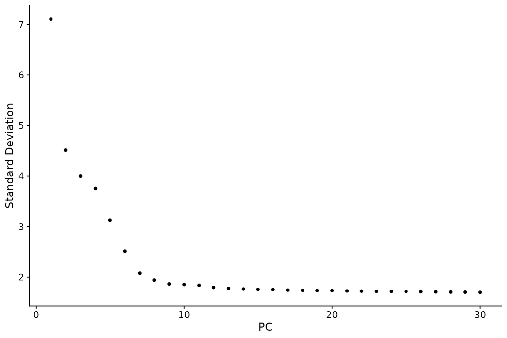

pca_elbow.png

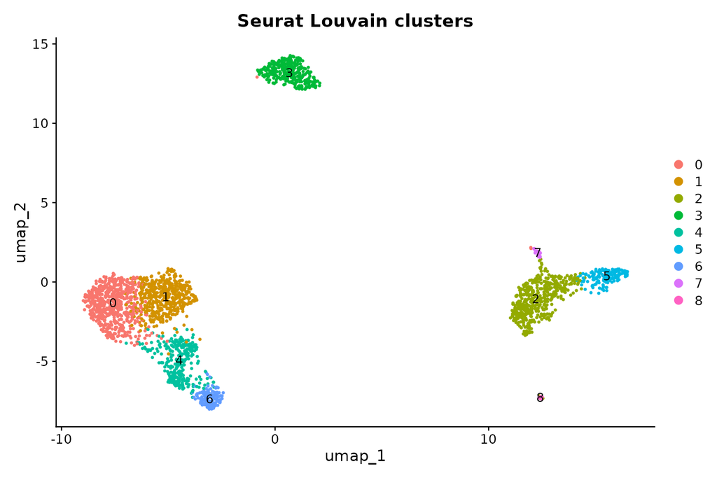

umap_clusters.png

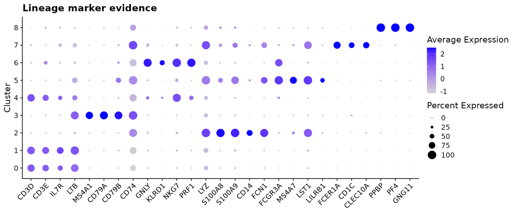

marker_dotplot.png

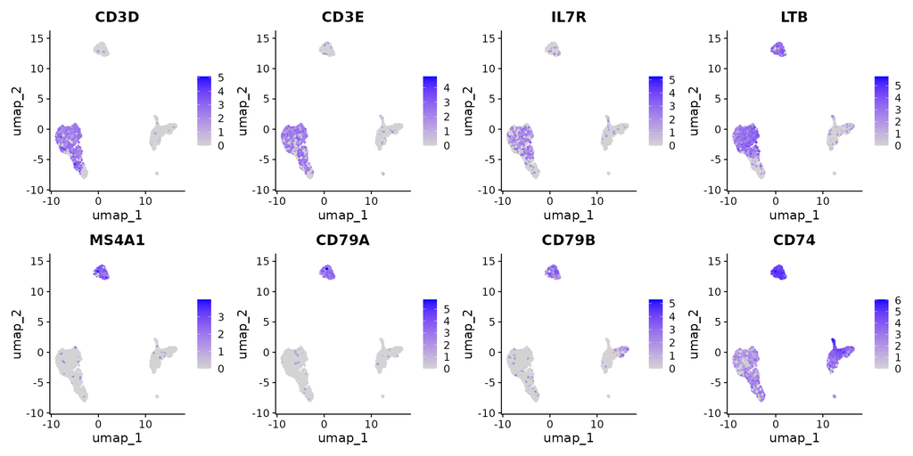

feature_markers.png

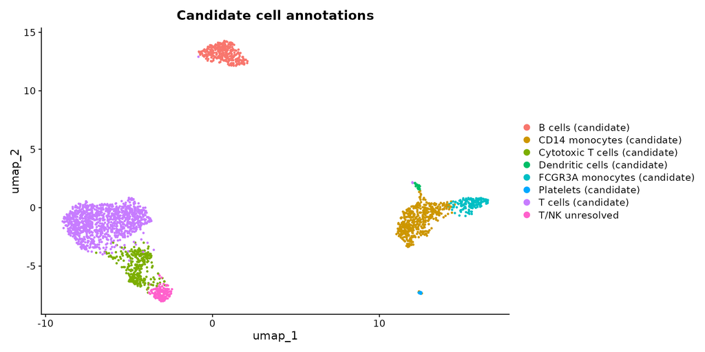

umap_celltypes.png

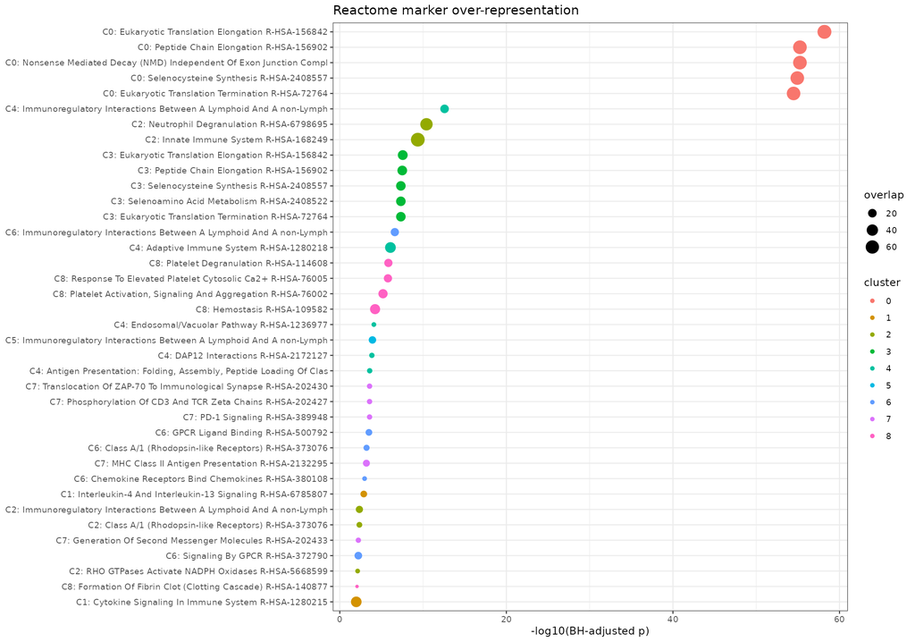

enrichment.png

| cluster | panel | panel_score | score_margin | t_core_fraction | nk_core_fraction | cytotoxic_fraction | cell_type | annotation_status | evidence |
| --- | --- | --- | --- | --- | --- | --- | --- | --- | --- |
| 0 | T cells | 0.6689190 | 0.5718718 | 0.52850877 | 0.04851974 | 0.08278509 | T cells (candidate) | candidate | Heuristic panel support; inspect marker plots before accepting |
| 1 | T cells | 0.7895015 | 0.6715347 | 0.56765677 | 0.06336634 | 0.11947195 | T cells (candidate) | candidate | Heuristic panel support; inspect marker plots before accepting |
| 2 | CD14 monocytes | 1.0000000 | 0.6796045 | 0.05327574 | 0.06803456 | 0.11447084 | CD14 monocytes (candidate) | candidate | Heuristic panel support; inspect marker plots before accepting |
| 3 | B cells | 0.9924451 | 0.7580114 | 0.04518072 | 0.03614458 | 0.06024096 | B cells (candidate) | candidate | Heuristic panel support; inspect marker plots before accepting |
| 4 | T cells | 0.5975512 | 0.2041054 | 0.52068966 | 0.23965517 | 0.57471264 | Cytotoxic T cells (candidate) | candidate | Heuristic panel support; inspect marker plots before accepting |
| 5 | FCGR3A monocytes | 1.0000000 | 0.5520648 | 0.06079665 | 0.07547170 | 0.18238994 | FCGR3A monocytes (candidate) | candidate | Heuristic panel support; inspect marker plots before accepting |
| 6 | NK cells | 1.0000000 | 0.7729049 | 0.15972222 | 0.75347222 | 0.97222222 | T/NK unresolved | candidate | Heuristic panel support; inspect marker plots before accepting |
| 7 | Dendritic cells | 1.0000000 | 0.6357684 | 0.08333333 | 0.16071429 | 0.20238095 | Dendritic cells (candidate) | candidate | Heuristic panel support; inspect marker plots before accepting |
| 8 | Platelets | 1.0000000 | 0.8870664 | 0.05128205 | 0.00000000 | 0.07692308 | Platelets (candidate) | candidate | Heuristic panel support; inspect marker plots before accepting |

## Cell label counts

| cell_type | cells |
| --- | --- |
| B cells (candidate) | 332 |
| CD14 monocytes (candidate) | 463 |
| Cytotoxic T cells (candidate) | 290 |
| Dendritic cells (candidate) | 28 |
| FCGR3A monocytes (candidate) | 159 |
| Platelets (candidate) | 13 |
| T cells (candidate) | 1113 |
| T/NK unresolved | 144 |

## Top cluster markers

| p_val | avg_log2FC | pct.1 | pct.2 | p_val_adj | gene | cluster |
| --- | --- | --- | --- | --- | --- | --- |
| 3.008098e-26 | 3.266883 | 0.105 | 0.014 | 4.067550e-22 | RP11-291B21.2 | 0 |
| 5.685474e-37 | 2.935380 | 0.163 | 0.025 | 7.687898e-33 | LINC00176 | 0 |
| 1.071929e-45 | 2.759188 | 0.212 | 0.036 | 1.449463e-41 | FHIT | 0 |
| 6.187285e-103 | 2.643232 | 0.482 | 0.099 | 8.366446e-99 | CCR7 | 0 |
| 3.046505e-22 | 2.627013 | 0.127 | 0.028 | 4.119484e-18 | SCGB3A1 | 0 |
| 2.787616e-32 | 2.430338 | 0.255 | 0.079 | 3.769414e-28 | LDLRAP1 | 0 |
| 5.783567e-31 | 2.409190 | 0.209 | 0.056 | 7.820540e-27 | TRABD2A | 0 |
| 8.401392e-24 | 2.400901 | 0.132 | 0.028 | 1.136036e-19 | RP11-664D1.1 | 0 |
| 6.619822e-32 | 2.282486 | 0.166 | 0.033 | 8.951323e-28 | NELL2 | 0 |
| 3.458668e-21 | 2.269960 | 0.125 | 0.028 | 4.676811e-17 | C14orf64 | 0 |
| 5.320399e-69 | 3.916472 | 0.216 | 0.016 | 7.194244e-65 | TNFRSF4 | 1 |
| 2.324090e-21 | 2.499808 | 0.113 | 0.021 | 3.142635e-17 | FUT7 | 1 |
| 3.206902e-21 | 2.416230 | 0.152 | 0.039 | 4.336373e-17 | TNFRSF25 | 1 |
| 9.386257e-24 | 2.405955 | 0.105 | 0.015 | 1.269210e-19 | TNFRSF18 | 1 |
| 5.635649e-17 | 2.354588 | 0.143 | 0.041 | 7.620524e-13 | PASK | 1 |
| 4.795092e-67 | 2.351129 | 0.414 | 0.096 | 6.483924e-63 | AQP3 | 1 |
| 5.309723e-26 | 2.283079 | 0.154 | 0.032 | 7.179808e-22 | CRIP2 | 1 |
| 1.992721e-15 | 2.212007 | 0.119 | 0.032 | 2.694558e-11 | GPR171 | 1 |
| 1.676114e-44 | 2.161878 | 0.271 | 0.058 | 2.266441e-40 | CD40LG | 1 |
| 1.484240e-19 | 2.084135 | 0.113 | 0.023 | 2.006990e-15 | CMTM8 | 1 |
| 7.728773e-72 | 8.128444 | 0.153 | 0.000 | 1.045085e-67 | CLEC4E | 2 |
| 4.067823e-52 | 7.911246 | 0.114 | 0.001 | 5.500510e-48 | C19orf59 | 2 |
| 3.630466e-54 | 7.875873 | 0.119 | 0.001 | 4.909116e-50 | RNASE2 | 2 |
| 3.310369e-134 | 7.514728 | 0.294 | 0.003 | 4.476281e-130 | FOLR3 | 2 |
| 3.144080e-115 | 6.709724 | 0.274 | 0.007 | 4.251425e-111 | S100A12 | 2 |
| 0.000000e+00 | 6.656122 | 0.974 | 0.119 | 0.000000e+00 | S100A8 | 2 |
| 0.000000e+00 | 6.201903 | 0.996 | 0.213 | 0.000000e+00 | S100A9 | 2 |
| 3.276036e-96 | 6.167013 | 0.227 | 0.005 | 4.429855e-92 | FCGR1A | 2 |
| 8.358072e-285 | 5.965241 | 0.667 | 0.027 | 1.130178e-280 | CD14 | 2 |
| 3.356627e-56 | 5.832584 | 0.136 | 0.003 | 4.538831e-52 | MGST1 | 2 |

[output cut: 60 more lines]

Wilcoxon tests compare each cluster with the other cells. Seurat uses Bonferroni-adjusted marker p-values. These are exploratory cluster markers, not donor-level disease tests.

## Methods and interpretation

RNA counts are retained. LogNormalize and VST precede variable-gene scaling, PCA, graph neighbors, Louvain clustering and R-native uwot UMAP.

Automatic labels use a documented marker-panel heuristic, not a probability. NKG7 and PRF1 alone do not distinguish NK from cytotoxic T cells. Review CD3D, CD3E and TRAC alongside GNLY and KLRD1.

Reactome over-representation uses each cluster's tested-gene universe and BH correction across every eligible pathway, including zero-overlap pathways.

The one-donor PBMC3k demo cannot support a disease/control comparison. Donor-level DESeq2 is a separate extension requiring independent donors and reviewed labels. FASTQ alignment, empty-droplet calling and full ambient-RNA estimation are outside this executed count-matrix demo.

## Configuration

```
list(project = "pbmc3k", seed = 42L, output_dir = "results/pbmc3k",
    input = list(mode = "demo", samples = "config/samples.csv"),
    qc = list(min_genes = 200L, max_genes = 2500L, max_pct_mt = 5,
        min_cells_per_gene = 3L, mitochondrial_pattern = "^MT-",
        overrides = list()), doublets = list(enabled = TRUE,
        remove = TRUE, expected_rate = 0.04), normalization = list(
        scale_factor = 10000, n_hvg = 2000L), embedding = list(
        n_pcs = 30L, dims = 1:20, k = 20L, resolution = 0.5,
        integration = "none", batch_key = "batch"), markers = list(
        min_pct = 0.1, min_log2fc = 0.25, max_adjusted_p = 0.05),
    annotation = list(panel = "config/markers.R", manual_labels = NULL,
        min_score = 0.25, min_margin = 0.1), enrichment = list(
        gmt = "resources/reactome_2022.gmt", min_size = 5L, max_size = 500L,
        top_genes = 200L))
```

## R package versions

| package | version |
| --- | --- |
| Seurat | 5.2.1 |
| SeuratObject | 5.0.2 |
| Matrix | 1.7.6 |
| ggplot2 | 3.5.2 |
| patchwork | 1.3.2 |
| scDblFinder | 1.20.2 |
| SingleCellExperiment | 1.28.0 |
| SummarizedExperiment | 1.36.0 |
| BiocParallel | 1.40.0 |
| harmony | 1.2.4 |
| DESeq2 | 1.46.0 |
| digest | 0.6.39 |
| jsonlite | 2.0.0 |
| base64enc | 0.1.6 |
| hdf5r | 1.3.12 |
| xgboost | 1.7.11.1 |
| uwot | 0.2.5 |

PBMC3k data: 10x Genomics, CC BY 4.0. Reactome data: CC0; Reactome_2022 snapshot distributed by Enrichr. See resources for source URLs and SHA-256 checksums.